# Comparativa de velocidad de escritura según el dispositivo y el tipo de test de velocidad

Gabriel Carbonell, Eduardo Rodríguez, Lucas Naranjo

7/3/2022

## Introducción

En 1829, William Austin Burt patentó una máquina llamada tipógrafo. A menudo se la cita como la «primera» máquina de escribir. Lo curioso de esta máquina es que, incluso en manos de su inventor, esta máquina era más lenta que la escritura manual. Burt y su promotor, John D. Sheldon, nunca hallaron comprador para la patente, y la máquina nunca fue comercializada. Entre 1829 y 1870 se patentaron en Europa y América muchas máquinas de imprimir o escribir, pero ninguna de ellas llegó a comercializarse.

La invención de la máquina de escribir permitió suplantar a los lentos copistas y dotó de mayor seriedad a los escritos comerciales y políticos. La máquina permitió acelerar el ritmo de las comunicaciones, marcó un punto importante en el desarrollo de las relaciones sociales y le permitió a la mujer ingresar masivamente al mundo laboral como dactilógrafa, entre los siglos XIX y XX. Podríamos decir de cierta manera que la máquina de escribir le abrió el camino a las máquinas eléctricas y por qué no a las computadoras.

La primera máquina de escribir con éxito comercial real fue inventada en 1872 por Christopher Sholes, Carlos Glidden y Samuel W. Soulé. En 1873, Remington inició la producción de su primera máquina de escribir.

La característica de ver lo que se iba mecanografiando a medida que se escribía se da por supuesta en la actualidad. Sin embargo, en la mayoría de las primeras máquinas de escribir, los tipos golpeaban subiendo contra el fondo del rodillo. Por ello, lo que se escribía no era visible hasta que las siguientes líneas escritas hacían que el papel se deslizase, dejándolo a la vista. La dificultad con cualquier otra disposición era asegurar que los tipos volvían a caer adecuadamente a su lugar cuando se soltaba la tecla. Esto fue finalmente logrado con diversos diseños mecánicos ingeniosos, y las llamadas «máquinas de escribir visibles» fueron comercializadas hacia 1895.

A mediados del siglo siguiente, llegaría la invención de los ordenadores cambiando la forma de escribir, digitalizando todo. Esto repercutiría en las máquinas de escribir siendo la última producida en 2012.

Debido a que nuestro profesor de planificación de la investigación Rubén nos mandó que diseñaramos un experimento, mis compañeros y yo nos pusimos a la obra.

Viendo que nuestra capacidad económica, tiempo y recursos son limitados para hacer algo muy grande que requiera de muchas personas involucradas (pues somos solo 3 integrantes) decidimos que un buen experimento (habiendo leído sobre las máquinas de escribir y picandonos la curiosidad) sería comprobar cómo de rápido escribe cada uno usando un teclado de ordenador y nuestros smartphones.

El experimento consiste en realizar una serie de test de la página *TypingTest.com*. En esta página podemos cambiar diferentes opciones para realizar los tests, entre las que están la dificultad, la duración en minutos y otras opciones como *blind typing* que ocultará lo que vamos escribiendo.

Nosotros elegimos el test medio y de 1 minuto de duración. Además realizaremos los test con el teclado del ordenador con la opción *blind typing* y sin ella. Lo repetiremos con el smartphone. Los resultados serán medidos en palabras por minuto.

Debido a que hemos elegido estas opciones el diseño de nuestro experimento quedará como:

- Unidad de observación: el sujeto retranscribiendo un texto digitalmente, en cada momento.
- Variable respuesta: palabras por minuto.
- Factor fijo: tipo de dispositivo con 2 niveles: teclado de ordenador y smartphone.
- Factor fijo: viendo el texto que se escribe y “blind typing” (sin ver el texto que se escribe)
- Bloque: las personas que realizan el experimento junto con sus características, diferencias etc.

Elegimos el primer factor fijo ya que pensamos que puede haber diferencia significativa entre los distintos dispositivos. Es fijo ya que nos interesa estudiar la media entre ambos y las diferencias que podamos encontrar, además de ser dos grupos que ya existen diferenciados en la naturaleza como tal.

El segundo factor fijo también es una diferencia clara en la naturaleza, además intentamos emular cuando las máquinas de escribir como hemos dicho antes, no veían lo que iban escribiendo. Intentaremos observar si se aprecian diferencias.

Hemos elegido los bloques ya que pensamos que existe variabilidad en el proceso y sobretodo en las personas que lo realizan ya que cada una es distinta con sus características pero no nos interesa estudiar las diferencias entre ellas, simplemente queremos no perder esta variabilidad comentada. No tendría sentido comparar la velocidad del sujeto A usando smartphone con la del sujeto B usando teclado físico. Si hiciesemos tal comparación, la varianza entre estas dos velocidades se puede deber a las diferentes habilidades de los sujetos o a la calidad del teclado o smartphone.

Primero realizaremos una serie de test nosotros para poder calcular cuántas réplicas necesitamos y la potencia necesaria. Después realizaremos los test necesarios que nos hayan salido y analizaremos mediante ANOVA si hay diferencias significativas. Por último realizaremos una conclusión para cerrar nuestras hipótesis.

## Cálculo de potencia

```r
piloto <- read.csv2("data/piloto.csv", header = TRUE, sep = ";")
piloto$Individual <- as.factor(piloto$Individual)
piloto$Device <- as.factor(piloto$Device)
piloto$Type <- as.factor(piloto$Type)
```

En primer lugar elegimos $\Delta$ = 6 :

```r
piloto.aov <- aov(Count ~ Individual + Device * Type, data = piloto)
summary(piloto.aov)
```

```
##             Df Sum Sq Mean Sq F value Pr(>F)
## Individual   2 260.17  130.08   4.745 0.0581 .
## Device       1 261.33  261.33   9.532 0.0215 *
## Type         1  40.33   40.33   1.471 0.2708
## Device:Type  1  21.33   21.33   0.778 0.4117
## Residuals    6 164.50   27.42
## ---
## Signif. codes:  0 '***' 0.001 '**' 0.01 '*' 0.05 '.' 0.1 ' ' 1
```

Usamos el $\sigma = \sqrt{mmE}$ para realizar el cálculo de potencia.

#Número de réplicas para efectos principales: Queremos detectar los efectos principales del dispositivo (2 niveles) y la visibilidad (2 niveles) para $\Delta = 6$ y $\sigma = 5.24$ ($\sqrt{mmE}$)

```r
sigma <- sqrt(27.42) ;
alpha <- .05;
Delta <- 6;
nlev <- c(2,2)
rmin <- 2;
rmax <- 9;
nreps <- c(rmin:rmax)
power <- Fpower2(alpha, nlev, nreps, Delta, sigma)
options(digits = 5)
power
```

```
##      alpha a b nreps Delta  sigma  powera  powerb
## [1,]  0.05 2 2     2     6 5.2364 0.24036 0.24036
## [2,]  0.05 2 2     3     6 5.2364 0.41582 0.41582
## [3,]  0.05 2 2     4     6 5.2364 0.55832 0.55832
## [4,]  0.05 2 2     5     6 5.2364 0.67233 0.67233
## [5,]  0.05 2 2     6     6 5.2364 0.76112 0.76112
## [6,]  0.05 2 2     7     6 5.2364 0.82852 0.82852
## [7,]  0.05 2 2     8     6 5.2364 0.87858 0.87858
## [8,]  0.05 2 2     9     6 5.2364 0.91507 0.91507
```

#Número de réplicas para interacciones:

Queremos detectar interacciones entre el dispositivo (2 niveles) y la viibilidad (2 niveles), con $\Delta = 6$ y suponiendo $\sigma = 5.24$ (lo tratamos como ANOVA de un factor con 2x2=4 niveles):

```r
sigma <- sqrt(27.42)
alpha <- .05
Delta <- 6
nlev <- 2*2
rmin <- 5
rmax <- 18
nreps <- c(rmin:rmax)
power <- Fpower1(alpha, nlev, nreps, Delta, sigma)
options(digits = 5)
power
```

```
##       alpha nlev nreps Delta  sigma   power
##  [1,]  0.05    4     5     6 5.2364 0.24068
##  [2,]  0.05    4     6     6 5.2364 0.29604
##  [3,]  0.05    4     7     6 5.2364 0.35150
##  [4,]  0.05    4     8     6 5.2364 0.40613
##  [5,]  0.05    4     9     6 5.2364 0.45918
##  [6,]  0.05    4    10     6 5.2364 0.51007
##  [7,]  0.05    4    11     6 5.2364 0.55836
##  [8,]  0.05    4    12     6 5.2364 0.60373
##  [9,]  0.05    4    13     6 5.2364 0.64599
## [10,]  0.05    4    14     6 5.2364 0.68505
## [11,]  0.05    4    15     6 5.2364 0.72090
## [12,]  0.05    4    16     6 5.2364 0.75358
## [13,]  0.05    4    17     6 5.2364 0.78321
## [14,]  0.05    4    18     6 5.2364 0.80991
```

Para ver una diferencia significativa con una potencia del 80% necesitaríamos 18 réplicas.

Puesto que hay tres bloques, cada bloque tendrá que repetir cada cruce de factores 6 veces.

## ANOVA

En primer lugar, cargamos los datos.

```r
palabras <- read.csv2("data/data.csv", header = TRUE, sep = ";")
palabras$Individual <- as.factor(palabras$Individual)
palabras$Device <- as.factor(palabras$Device)
palabras$Type <- as.factor(palabras$Type)
```

### ANOVA promediando pseudo-réplicas

#Justificación de promediar las pseudo réplicas

Hemos visto en clase que en caso de ser posible, es preferible aumentar el número de bloques al número de réplicas dentro de cada bloque. En nuestra situación, los test se pueden repetir facilmente y con coste nulo, por eso decidimos que sería más fácil aumentar el número de veces que cada bloque hace el test. En parte la idea de promediar las pseudo réplicas viene dada por un ejemplo que vimos en clase, el de la ditancia de lanzamiento de pelotas de golf. En ese experimento, no interesaba observar la diferencia entre jugadores, por eso la creación d ebloques es necesaria. Como en ese experimente también era relativemente simple de hacer y era rápido pedirle más réplicas a cada jugador, así se hizo. En la página 127 de libro DAEWR recomiendan promediar las pseudo-réplicas de cada jugador de golf.

Al haberse realizado seis pseudo-réplicas por bloque, en primer lugar se realiza una promediación de estas:

```r
palabras.mean <- aggregate(palabras$Count,
                           by = list(palabras$Individual,
                                     palabras$Device,
                                     palabras$Type),
                           FUN=mean)
palabras.mean <- rename(palabras.mean,
                        Individual = Group.1,
                        Device = Group.2,
                        Type = Group.3,
                        Count = x)
```

A continuación, realizamos ANOVA con el siguiente modelo:

$$Palabras_i = \mu + \beta_{Individuo,I(i)} + \beta_{Dispositivo, d(i)} + \beta_{Test,t(i)} + \alpha\beta_{d(i),t(i)}+\epsilon_i$$

```r
palabras.aov.mean <- aov(Count ~ Device + Type + Individual + Device*Type, data = palabras.mean)
summary(palabras.aov.mean)
```

```
##             Df Sum Sq Mean Sq F value  Pr(>F)
## Device       1  300.0   300.0   40.39 0.00071 ***
## Type         1    2.1     2.1    0.28 0.61541
## Individual   2  106.4    53.2    7.16 0.02571 *
## Device:Type  1    0.3     0.3    0.04 0.83925
## Residuals    6   44.6     7.4
## ---
## Signif. codes:  0 '***' 0.001 '**' 0.01 '*' 0.05 '.' 0.1 ' ' 1
```

Vemos que solo el dispositivo es significativo. También el bloque. El tipo de test o su interacción con el dispositivo no lo son. Por ello, consideramos el modelo sin interacción:

$$Palabras_i = \mu + \beta_{Individuo,I(i)} + \beta_{Dispositivo, d(i)} + \beta_{Test,t(i)} +\epsilon_i$$

```r
palabras.aov.mean <- aov(Count ~ Device + Type + Individual, data = palabras.mean)
summary(palabras.aov.mean)
```

```
##             Df Sum Sq Mean Sq F value  Pr(>F)
## Device       1  300.0   300.0   46.77 0.00024 ***
## Type         1    2.1     2.1    0.32 0.58657
## Individual   2  106.4    53.2    8.30 0.01423 *
## Residuals    7   44.9     6.4
## ---
## Signif. codes:  0 '***' 0.001 '**' 0.01 '*' 0.05 '.' 0.1 ' ' 1
```

A continuación, comprobamos las condiciones de aplicabilidad.

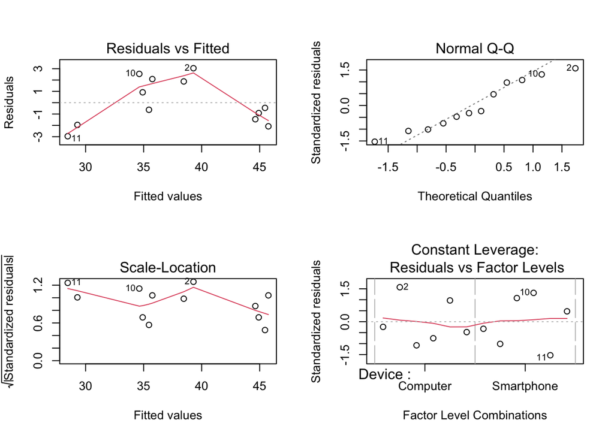

```r
par(mfrow = c(2,2))
plot(palabras.aov.mean)
```

### ANOVA sin pseudo-réplicas

Realizamos el ANOVA a partir del modelo propuesto.

```r
palabras.aov <- aov(Count ~ Device + Type + Individual + Device*Type, data = palabras)
summary(palabras.aov)
```

```
##             Df Sum Sq Mean Sq F value  Pr(>F)
## Device       1   1800    1800   84.95 1.8e-13 ***
## Type         1     13      13    0.59    0.45
## Individual   2    639     319   15.07 4.1e-06 ***
## Device:Type  1      2       2    0.09    0.76
## Residuals   66   1398      21
## ---
## Signif. codes:  0 '***' 0.001 '**' 0.01 '*' 0.05 '.' 0.1 ' ' 1
```

Observamos que los factores significativos son el dispositivo empleado y el bloque en sí. Tanto el tipo de test (texto medio o *blind test*) como su interacción son poco significativos. A continuación, comprobamos las condiciones de aplicabilidad.

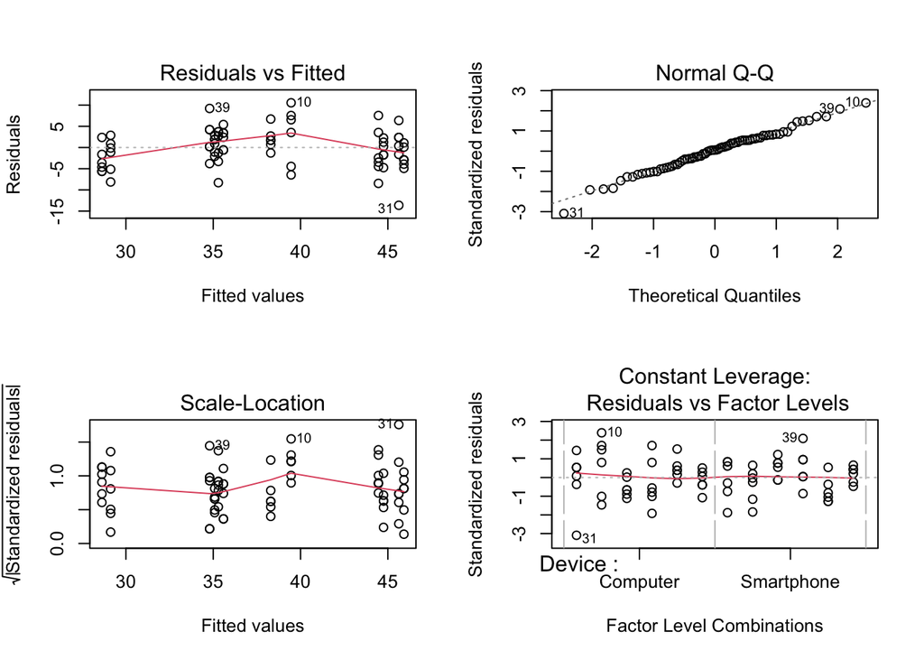

```r
par(mfrow = c(2,2))
plot(palabras.aov)
```

Se observa que la varianza de los residuos es estable, y que los residuos se ajustan a la normalidad.

## Estimación de parámetros del modelo

Realizamos una estimación de los parámetros del modelo propuesto, sin interacción y promediando pseudo-réplicas.

```r
mu <- mean(palabras.mean$Count); mu
```

```
## [1] 38.083
```

```r
model.tables(palabras.aov.mean)
```

```
## Tables of effects
##
##  Device
## Device
##   Computer Smartphone
##          5         -5
##
##  Type
## Type
##   Blind  Medium
##  0.4167 -0.4167
##
##  Individual
## Individual
##      1      2      3
##  1.958 -4.208  2.250
```

Por tanto, nuestro modelo tendría la fórmula:

$$\begin{array}{l}
Palabras_i = 38.083 + 1.958 \ I(I_i = 1) -4.208 \ I(I_i = 2) + 2.250 \ I(I_i = 3) \\
+5 \ I(d_i = Ordenador) - 5 \ I(d_i = Smartphone) -
0.4167 \ I(t_i = Medio) + 0.4167 \ I(t_i = Blind)
\end{array}$$
El efecto más significativo es el del tipo de dispositivo. Si miramos los estimadores del sus parámetros podemos observar que de media, con teclado se escriben 10 palabras más por minuto. También se observan hasta más de 6 palabras por minuto e diferencia entre el individuo más lento y el más veloz, lo que sugiere que hacer bloques ha sido una buena idea. El último resultado a tener en cuenta,un tanto sorprendente aunque no tan significativo, es que de media se escribe ligeramente más rápido en los test a ciegas que en el test con visibiidad. Probablemente esto se deba a que En el test ha ciegas no “perdemos” tiempo releyendo lo que hemos escrito.

## Análisis post

```r
palabras.tukey <- TukeyHSD(palabras.aov.mean, ordered = T, which = "Device")
palabras.tukey
```

```
##   Tukey multiple comparisons of means
##     95% family-wise confidence level
##     factor levels have been ordered
##
## Fit: aov(formula = Count ~ Device + Type + Individual, data = palabras.mean)
##
## $Device
##                     diff    lwr    upr   p adj
## Computer-Smartphone   10 6.5423 13.458 0.00024
```

## Conclusiones

Este estudio, que ha sido un mero ejercicio de aplicación de los conociemientos que hemos estudiado en la asignatura nos ha aportado también algo de información sobre la mecanografía. Como era de esperar En un teclado físico parecemos ser generalmente más rápidos que en un smartphone, pese a que seguramente escribimos más con smartphone que con teclado. Por mucho que el uso de las pantallas táctiles se popularizen, en un teclado físico estamos usando nuestros 10 dedos y en un smartphone solo los dos pulgares. El consejo que sugiere este estudio es un tanto obvio: si quieres ecribir más rápido usa un teclado físico. Una de las condiciones que permite dar este consejo generalizado es que la interaccion dispositivo-individuo no salga significativa. Caso contrario, no podríamos aconsejar un dispositivo por encima de otro puesto que una interacción significtiva se traduce en que según a qué individuo el dispositivo le hace un efecto u otro.

…